# W0791252_Marketing_Project

Name: Amir Dahya

S_ID: 0791252

Section:006

To complete this project i am using below mentioned library:

1. Pandas
2. Matplotlib for plotting
3. Scikit-Learn
4. Natural Language Toolkit

```python
#import basic libraries
import numpy as np
import pandas as pd
import matplotlib.pyplot as plt
import seaborn as sns
```

```python
from google.colab import drive
drive.mount('/content/drive')
```

```python
df = pd.read_csv("/content/drive/MyDrive/DAB_303/my_project_303/amazon_alexa.tsv",sep='\t')
```

#### Here, I want to begin with an overview of the dataset and a steps of Exploratory Data Analysis (EDA) to get a better understanding of the data and see if we can get any significant patterns/insights.

```python
df.head(10)
```

|  | rating | date | variation | verified_reviews | feedback |
| --- | --- | --- | --- | --- | --- |
| 0 | 5 | 31-Jul-18 | Charcoal Fabric | Love my Echo! | 1 |
| 1 | 5 | 31-Jul-18 | Charcoal Fabric | Loved it! | 1 |
| 2 | 4 | 31-Jul-18 | Walnut Finish | Sometimes while playing a game, you can answer... | 1 |
| 3 | 5 | 31-Jul-18 | Charcoal Fabric | I have had a lot of fun with this thing. My 4 ... | 1 |
| 4 | 5 | 31-Jul-18 | Charcoal Fabric | Music | 1 |
| 5 | 5 | 31-Jul-18 | Heather Gray Fabric | I received the echo as a gift. I needed anothe... | 1 |
| 6 | 3 | 31-Jul-18 | Sandstone Fabric | Without having a cellphone, I cannot use many ... | 1 |
| 7 | 5 | 31-Jul-18 | Charcoal Fabric | I think this is the 5th one I've purchased. I'... | 1 |
| 8 | 5 | 30-Jul-18 | Heather Gray Fabric | looks great | 1 |
| 9 | 5 | 30-Jul-18 | Heather Gray Fabric | Love it! I’ve listened to songs I haven’t hear... | 1 |

```python
df.tail(10)
```

|  | rating | date | variation | verified_reviews | feedback |
| --- | --- | --- | --- | --- | --- |
| 3140 | 4 | 30-Jul-18 | White Dot | Barry | 1 |
| 3141 | 3 | 30-Jul-18 | Black Dot |  | 1 |
| 3142 | 4 | 30-Jul-18 | White Dot | My three year old loves it. Good for doing ba... | 1 |
| 3143 | 5 | 30-Jul-18 | Black Dot | Awesome device wish I bought one ages ago. | 1 |
| 3144 | 5 | 30-Jul-18 | Black Dot | love it | 1 |
| 3145 | 5 | 30-Jul-18 | Black Dot | Perfect for kids, adults and everyone in betwe... | 1 |
| 3146 | 5 | 30-Jul-18 | Black Dot | Listening to music, searching locations, check... | 1 |
| 3147 | 5 | 30-Jul-18 | Black Dot | I do love these things, i have them running my... | 1 |
| 3148 | 5 | 30-Jul-18 | White Dot | Only complaint I have is that the sound qualit... | 1 |
| 3149 | 4 | 29-Jul-18 | Black Dot | Good | 1 |

```python
# Check the shape
df.shape
```

```
(3150, 5)
```

```python
#check summary of dataframes
df.info()
```

```
<class 'pandas.core.frame.DataFrame'>
RangeIndex: 3150 entries, 0 to 3149
Data columns (total 5 columns):
 #   Column            Non-Null Count  Dtype
---  ------            --------------  -----
 0   rating            3150 non-null   int64
 1   date              3150 non-null   object
 2   variation         3150 non-null   object
 3   verified_reviews  3150 non-null   object
 4   feedback          3150 non-null   int64
dtypes: int64(2), object(3)
memory usage: 123.2+ KB
```

```python
# check if we have missing values
df.isnull().sum()
```

```
rating              0
date                0
variation           0
verified_reviews    0
feedback            0
dtype: int64
```

```python
# unique values
df.nunique()
```

```
rating                 5
date                  77
variation             16
verified_reviews    2301
feedback               2
dtype: int64
```

```python
rating_count=df.rating.value_counts()
rating_count
```

```
5    2286
4     455
1     161
3     152
2      96
Name: rating, dtype: int64
```

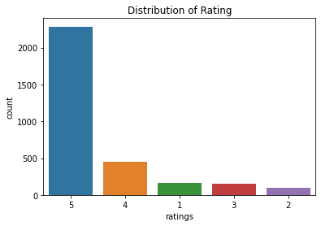

```python
sns.countplot(data=df, x='rating', order=rating_count.index)
plt.xlabel("ratings")
plt.title("Distribution of Rating");
```

Now,We'll try to classify and analyse the negative reviews that are present in dataset.

```python
#Want to see negative and positive impact, so will replacing scores of 1,2 with 0 as a negative and 3,4,5 with 1 as positive

def sentiment_score(score):
    if(score == 1 or score == 2):
        return 0
    else:
        return 1
```

```python
df.rating = df.rating.apply(sentiment_score)
df.rating.value_counts()
```

```
1    2893
0     257
Name: rating, dtype: int64
```

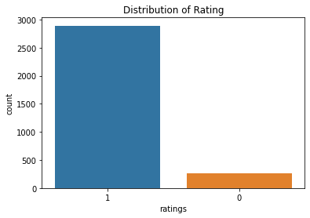

```python
sns.countplot(data=df, x='rating', order=df.rating.value_counts().index)
plt.xlabel("ratings")
plt.title("Distribution of Rating");
```

We will also plot a chart to see the relative distribution of ‘feedback’ values. Here, Feedback 1 means that the customer was satisfied with product and feedback 0 means that the customer wasn’t satisfied with product.

```python
df.feedback.value_counts()
```

```
1    2893
0     257
Name: feedback, dtype: int64
```

```
<function matplotlib.pyplot.show(*args, **kw)>
```

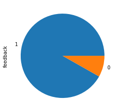

```python
df.feedback.value_counts().plot.pie()
plt.show
```

```python
df.variation.value_counts()
```

```
Black  Dot                      516
Charcoal Fabric                 430
Configuration: Fire TV Stick    350
Black  Plus                     270
Black  Show                     265
Black                           261
Black  Spot                     241
White  Dot                      184
Heather Gray Fabric             157
White  Spot                     109
White                            91
Sandstone Fabric                 90
White  Show                      85
White  Plus                      78
Oak Finish                       14
Walnut Finish                     9
Name: variation, dtype: int64
```

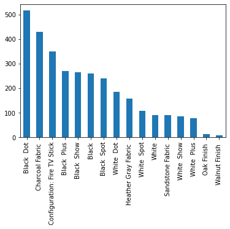

```python
df.variation.value_counts().plot.bar()
```

```python
df.head()
```

|  | rating | date | variation | verified_reviews | feedback |
| --- | --- | --- | --- | --- | --- |
| 0 | 1 | 31-Jul-18 | Charcoal Fabric | Love my Echo! | 1 |
| 1 | 1 | 31-Jul-18 | Charcoal Fabric | Loved it! | 1 |
| 2 | 1 | 31-Jul-18 | Walnut Finish | Sometimes while playing a game, you can answer... | 1 |
| 3 | 1 | 31-Jul-18 | Charcoal Fabric | I have had a lot of fun with this thing. My 4 ... | 1 |
| 4 | 1 | 31-Jul-18 | Charcoal Fabric | Music | 1 |

```python
df.shape
```

```
(3150, 5)
```

```python
df.tail()
```

|  | rating | date | variation | verified_reviews | feedback |
| --- | --- | --- | --- | --- | --- |
| 3145 | 1 | 30-Jul-18 | Black Dot | Perfect for kids, adults and everyone in betwe... | 1 |
| 3146 | 1 | 30-Jul-18 | Black Dot | Listening to music, searching locations, check... | 1 |
| 3147 | 1 | 30-Jul-18 | Black Dot | I do love these things, i have them running my... | 1 |
| 3148 | 1 | 30-Jul-18 | White Dot | Only complaint I have is that the sound qualit... | 1 |
| 3149 | 1 | 29-Jul-18 | Black Dot | Good | 1 |

```python
# we`ll Summarize the data and set the index continuous basis

df["index"] = range(0,3150)
df= df.set_index("index")
```

```python
df.head()
```

| index | rating | date | variation | verified_reviews | feedback |
| --- | --- | --- | --- | --- | --- |
| 0 | 1 | 31-Jul-18 | Charcoal Fabric | Love my Echo! | 1 |
| 1 | 1 | 31-Jul-18 | Charcoal Fabric | Loved it! | 1 |
| 2 | 1 | 31-Jul-18 | Walnut Finish | Sometimes while playing a game, you can answer... | 1 |
| 3 | 1 | 31-Jul-18 | Charcoal Fabric | I have had a lot of fun with this thing. My 4 ... | 1 |
| 4 | 1 | 31-Jul-18 | Charcoal Fabric | Music | 1 |

```python
# Clean the text by removing any extra characters
import re # tools for cleaning text
import nltk # library to perform NLP
nltk.download('stopwords') # tool to remove the non-essential words. It is a list of words
from nltk.corpus import stopwords
# Stemming means taking the root of the word such as love from loved or loving
from nltk.stem.porter import PorterStemmer
```

```python
# Steps for cleaning the first review and apply for loop on all the reviews
corpus = [] # Build a new list for all the words from all the reviews
# corpus is a collection of text and a common term used in NLP
for i in range (0, 3150):
    review = re.sub('[^a-zA-Z]', ' ', df['verified_reviews'][i] )
    review = review.lower()
    review = review.split()
    ps =PorterStemmer()
    review = [ps.stem(word) for word in review if not  word in set(stopwords.words('english'))]
    review = ' '.join(review)
    corpus.append(review)
```